# breast_cancer

Prompt: Give Python code to read a breastcancer.csv file into a pandas DataFrame

```python
import pandas as pd

# Read the breast-cancer.csv file into a pandas DataFrame
df = pd.read_csv('/content/breast-cancer.csv')

# Display the first few rows of the DataFrame
print(df.head())
```

```
         id diagnosis  radius_mean  texture_mean  perimeter_mean  area_mean  \
0    842302         M        17.99         10.38          122.80     1001.0
1    842517         M        20.57         17.77          132.90     1326.0
2  84300903         M        19.69         21.25          130.00     1203.0
3  84348301         M        11.42         20.38           77.58      386.1
4  84358402         M        20.29         14.34          135.10     1297.0

   smoothness_mean  compactness_mean  concavity_mean  concave points_mean  \
0          0.11840           0.27760          0.3001              0.14710
1          0.08474           0.07864          0.0869              0.07017
2          0.10960           0.15990          0.1974              0.12790
3          0.14250           0.28390          0.2414              0.10520
4          0.10030           0.13280          0.1980              0.10430

   ...  radius_worst  texture_worst  perimeter_worst  area_worst  \
```

[output cut: 21 more lines]

Prompt: Give Python code to perform exploratory data analysis including checking for null values, data types, class distribution (malignant vs benign), and summary statistics

```python
# Check for null values
print("\nNull Values:\n", df.isnull().sum())

# Check data types
print("\nData Types:\n", df.info())

# Get class distribution (Malignant vs. Benign)
# Assuming 'diagnosis' column contains this information (M for Malignant, B for Benign)
print("\nClass Distribution (diagnosis):\n", df['diagnosis'].value_counts())

# Display summary statistics
print("\nSummary Statistics:\n", df.describe())
```

```
Null Values:
 id                         0
diagnosis                  0
radius_mean                0
texture_mean               0
perimeter_mean             0
area_mean                  0
smoothness_mean            0
compactness_mean           0
concavity_mean             0
concave points_mean        0
symmetry_mean              0
fractal_dimension_mean     0
radius_se                  0
texture_se                 0
perimeter_se               0
area_se                    0
smoothness_se              0
compactness_se             0
concavity_se               0
concave points_se          0
symmetry_se                0
fractal_dimension_se       0
radius_worst               0
texture_worst              0
perimeter_worst            0
area_worst                 0
smoothness_worst           0
compactness_worst          0
concavity_worst            0
concave points_worst       0
symmetry_worst             0
fractal_dimension_worst    0
dtype: int64
<class 'pandas.core.frame.DataFrame'>
RangeIndex: 569 entries, 0 to 568
Data columns (total 32 columns):
 #   Column                   Non-Null Count  Dtype
---  ------                   --------------  -----
 0   id                       569 non-null    int64
```

[output cut: 80 more lines]

```
50%     686.500000          0.131300           0.211900         0.226700
75%    1084.000000          0.146000           0.339100         0.382900
max    4254.000000          0.222600           1.058000         1.252000

       concave points_worst  symmetry_worst  fractal_dimension_worst
count            569.000000      569.000000               569.000000
mean               0.114606        0.290076                 0.083946
std                0.065732        0.061867                 0.018061
min                0.000000        0.156500                 0.055040
25%                0.064930        0.250400                 0.071460
50%                0.099930        0.282200                 0.080040
75%                0.161400        0.317900                 0.092080
max                0.291000        0.663800                 0.207500

[8 rows x 31 columns]
```

Prompt: Give Python code to convert the diagnosis column (malignant/benign) into numerical labels using label encoding

```python
from sklearn.preprocessing import LabelEncoder

# Initialize LabelEncoder
label_encoder = LabelEncoder()

# Apply label encoding to the 'diagnosis' column
df['diagnosis'] = label_encoder.fit_transform(df['diagnosis'])

# Display the mapping of original labels to numerical labels
print("Original labels and their numerical encoding:")
for i, item in enumerate(label_encoder.classes_):
    print(f"{item} : {i}")

# Display the first few rows of the DataFrame with the updated 'diagnosis' column
print("\nDataFrame head after label encoding:\n", df.head())
```

```
Original labels and their numerical encoding:
B : 0
M : 1

DataFrame head after label encoding:
          id  diagnosis  radius_mean  texture_mean  perimeter_mean  area_mean  \
0    842302          1        17.99         10.38          122.80     1001.0
1    842517          1        20.57         17.77          132.90     1326.0
2  84300903          1        19.69         21.25          130.00     1203.0
3  84348301          1        11.42         20.38           77.58      386.1
4  84358402          1        20.29         14.34          135.10     1297.0

   smoothness_mean  compactness_mean  concavity_mean  concave points_mean  \
0          0.11840           0.27760          0.3001              0.14710
1          0.08474           0.07864          0.0869              0.07017
2          0.10960           0.15990          0.1974              0.12790
3          0.14250           0.28390          0.2414              0.10520
4          0.10030           0.13280          0.1980              0.10430

   ...  radius_worst  texture_worst  perimeter_worst  area_worst  \
0  ...         25.38          17.33           184.60      2019.0
1  ...         24.99          23.41           158.80      1956.0
2  ...         23.57          25.53           152.50      1709.0
3  ...         14.91          26.50            98.87       567.7
4  ...         22.54          16.67           152.20      1575.0

   smoothness_worst  compactness_worst  concavity_worst  concave points_worst  \
0            0.1622             0.6656           0.7119                0.2654
1            0.1238             0.1866           0.2416                0.1860
2            0.1444             0.4245           0.4504                0.2430
3            0.2098             0.8663           0.6869                0.2575
4            0.1374             0.2050           0.4000                0.1625

   symmetry_worst  fractal_dimension_worst
0          0.4601                  0.11890
1          0.2750                  0.08902
2          0.3613                  0.08758
3          0.6638                  0.17300
4          0.2364                  0.07678

[5 rows x 32 columns]
```

Prompt: Give Python code to separate features (X) and target variable (y) from the dataset

```python
# Separate features (X) and target variable (y)
X = df.drop(['id', 'diagnosis'], axis=1)
y = df['diagnosis']

print("Features (X) shape:", X.shape)
print("Target variable (y) shape:", y.shape)
print("\nFirst 5 rows of X:\n", X.head())
print("\nFirst 5 values of y:\n", y.head())
```

```
Features (X) shape: (569, 30)
Target variable (y) shape: (569,)

First 5 rows of X:
    radius_mean  texture_mean  perimeter_mean  area_mean  smoothness_mean  \
0        17.99         10.38          122.80     1001.0          0.11840
1        20.57         17.77          132.90     1326.0          0.08474
2        19.69         21.25          130.00     1203.0          0.10960
3        11.42         20.38           77.58      386.1          0.14250
4        20.29         14.34          135.10     1297.0          0.10030

   compactness_mean  concavity_mean  concave points_mean  symmetry_mean  \
0           0.27760          0.3001              0.14710         0.2419
1           0.07864          0.0869              0.07017         0.1812
2           0.15990          0.1974              0.12790         0.2069
3           0.28390          0.2414              0.10520         0.2597
4           0.13280          0.1980              0.10430         0.1809

   fractal_dimension_mean  ...  radius_worst  texture_worst  perimeter_worst  \
0                 0.07871  ...         25.38          17.33           184.60
1                 0.05667  ...         24.99          23.41           158.80
2                 0.05999  ...         23.57          25.53           152.50
3                 0.09744  ...         14.91          26.50            98.87
4                 0.05883  ...         22.54          16.67           152.20

   area_worst  smoothness_worst  compactness_worst  concavity_worst  \
0      2019.0            0.1622             0.6656           0.7119
1      1956.0            0.1238             0.1866           0.2416
2      1709.0            0.1444             0.4245           0.4504
3       567.7            0.2098             0.8663           0.6869
4      1575.0            0.1374             0.2050           0.4000

   concave points_worst  symmetry_worst  fractal_dimension_worst
0                0.2654          0.4601                  0.11890
1                0.1860          0.2750                  0.08902
2                0.2430          0.3613                  0.08758
3                0.2575          0.6638                  0.17300
4                0.1625          0.2364                  0.07678

[5 rows x 30 columns]

First 5 values of y:
 0    1
1    1
2    1
3    1
4    1
Name: diagnosis, dtype: int64
```

Prompt: Give Python code to split the dataset into training and testing sets with 75 percent training and 25 percent testing using train_test_split with random_state for reproducibility

```python
from sklearn.model_selection import train_test_split

# Split the dataset into training and testing sets
X_train, X_test, y_train, y_test = train_test_split(X, y, test_size=0.25, random_state=42)

print("X_train shape:", X_train.shape)
print("X_test shape:", X_test.shape)
print("y_train shape:", y_train.shape)
print("y_test shape:", y_test.shape)
```

```
X_train shape: (426, 30)
X_test shape: (143, 30)
y_train shape: (426,)
y_test shape: (143,)
```

Prompt: Give Python code to standardize the feature variables using StandardScaler for both training and testing data

```python
from sklearn.preprocessing import StandardScaler

# Initialize StandardScaler
scaler = StandardScaler()

# Fit the scaler on the training data and transform it
X_train_scaled = scaler.fit_transform(X_train)

# Transform the testing data using the fitted scaler
X_test_scaled = scaler.transform(X_test)

print("X_train_scaled shape:", X_train_scaled.shape)
print("X_test_scaled shape:", X_test_scaled.shape)
print("\nFirst 5 rows of X_train_scaled:\n", X_train_scaled[:5])
print("\nFirst 5 rows of X_test_scaled:\n", X_test_scaled[:5])
```

```
X_train_scaled shape: (426, 30)
X_test_scaled shape: (143, 30)

First 5 rows of X_train_scaled:
 [[-0.34913849 -1.43851335 -0.41172595 -0.39047943 -1.86366229 -1.26860704
  -0.82617052 -0.95286585 -1.72936805 -0.9415409  -0.86971355 -1.35865347
  -0.83481506 -0.57230673 -0.74586846 -0.65398319 -0.52583524 -0.94677147
  -0.53781728 -0.63449458 -0.54268486 -1.65565452 -0.58986401 -0.52555985
  -1.51066925 -0.89149994 -0.75021715 -0.91671059 -0.92508585 -0.80841115]
 [-0.20468665  0.31264011 -0.13367256 -0.27587995  1.07807258  0.86354605
   0.72631375  0.89844062  1.17876963  1.47437716 -0.04022275 -0.50962253
   0.10947722 -0.13472838 -0.52489487 -0.14934475  0.07460028  0.23747244
  -0.43028253  0.08289146  0.04148684  0.68989862  0.19412774 -0.05193356
   1.12941497  0.92394223  1.22221738  1.43655962  1.14955889  1.56911143]
 [-0.32931176 -0.21507235 -0.31739376 -0.36435749 -1.57987983 -0.45745127
  -0.59730963 -0.76458843  0.27534303 -0.50102373 -0.58145327  0.16798362
  -0.22279145 -0.41532889 -1.10240272  0.64491227  0.07460028 -0.19098971
   0.72884203 -0.02896707 -0.43590079 -0.14898547 -0.32015874 -0.44603172
  -1.63439626 -0.10675178 -0.53989122 -0.7237126   0.53496977 -0.61934827]
 [ 1.02740257  2.08982423  1.04692153  0.91758377  0.31630299  0.56203731
   1.04852746  0.93043721 -0.32569698 -0.47747407 -0.0433674  -0.24034582
   0.00444977  0.07957869 -0.75136854 -0.28647476  0.15632623 -0.11931389
  -1.01547163 -0.45738524  1.11351518  2.16500569  1.16579318  0.99769598
   0.38360411  0.86094792  1.87281887  1.31069137  0.15288395  0.42163646]
 [ 1.82896865  0.69600073  1.76368137  1.78382103 -0.33367351  0.62817471
   0.97466029  1.26574025 -0.13157226 -1.71313858  1.60024033  0.50090086
   1.98851384  1.49196237  0.35188175  0.58896322  0.75409315  2.51676368
   1.40906184 -0.52860184  1.47155589  0.38756811  1.55627556  1.38559484
  -0.57775902  0.29667982  0.59576815  1.23299491  0.05045243 -1.40635096]]

First 5 rows of X_test_scaled:
 [[-0.46809882 -0.14171322 -0.44468042 -0.485979    0.29337107  0.06406159
  -0.09450341 -0.25211422  0.46573459  0.1555962  -0.02100539 -0.30104344
  -0.17505169 -0.20519121 -0.02697634 -0.34352085 -0.17591476 -0.23558801
  -0.33400142 -0.07333762 -0.26002114 -0.144002   -0.32802893 -0.34684297
   0.49138024 -0.06654265 -0.00300662 -0.17331092  0.22117163  0.23655985]
 [ 1.36445686  0.49958757  1.30643802  1.3344113  -0.39171992  0.00765028
   0.26145997  0.84000058 -0.81474195 -1.1077738   1.35111356 -0.75443626
   1.25188947  1.16570695 -0.83872267 -0.48558754 -0.32001928  0.2948131
  -0.82916142 -0.77730064  1.81075236  0.17826238  1.78632719  1.75755266
  -0.51309334 -0.09468904  0.00504413  1.0294302  -0.53161875 -0.99405722]
 [ 0.37878549  0.06653205  0.40430925  0.26397349  0.97774544  0.38502251
   0.75305876  0.87596368  0.48813359 -0.64370697  0.25223041 -0.77577239
   0.10995462  0.17047158 -0.25765595 -0.57773891 -0.13855433 -0.14639142
  -0.81540698 -0.49280711  0.63822136  0.0819153   0.54525918  0.49998099
   1.0087057  -0.05582021  0.5605461   0.6020997  -0.06661217 -0.17972015]
 [-0.48792555 -0.35942419 -0.42902705 -0.52558323  0.70542894  0.56592775
  -0.12812571 -0.52236636  0.04015346  1.16546103 -0.78760305  0.46411443
  -0.31492917 -0.51497751  0.95883118  0.41563089  0.54460787 -0.02852451
   0.17241223  0.828615   -0.69762645 -0.43138209 -0.52296742 -0.63395898
   0.59484533  0.10166554 -0.13785673 -0.6053032  -0.52348926  0.58336494]
 [-0.731511   -1.12614544 -0.70996395 -0.70787505  0.3069869   0.18466508
  -0.25599234 -0.57657545  0.06628564  0.72217331 -0.43225673  1.03062554
  -0.58991013 -0.40177834  1.65442887  0.86377176  0.77544197  0.49231982
  -0.26147798  0.64479415 -0.82744239 -0.96793568 -0.85079099 -0.73669019
   0.14218556 -0.24078221 -0.44277901 -0.6755408  -0.89256791 -0.1142315 ]]
```

Prompt: Give Python code to train Support Vector Machine, decision tree and random forest classifiers on the training data and print training and testing accuracy for each. perform parameter tuning for decision trees and random forest

```python
from sklearn.svm import SVC
from sklearn.tree import DecisionTreeClassifier
from sklearn.ensemble import RandomForestClassifier
from sklearn.metrics import accuracy_score
from sklearn.model_selection import GridSearchCV

# --- Support Vector Machine (SVM) ---
print("\n--- Support Vector Machine (SVM) ---")
svm_model = SVC(random_state=42)
svm_model.fit(X_train_scaled, y_train)

y_train_pred_svm = svm_model.predict(X_train_scaled)
y_test_pred_svm = svm_model.predict(X_test_scaled)

print(f"SVM Training Accuracy: {accuracy_score(y_train, y_train_pred_svm):.4f}")
print(f"SVM Testing Accuracy: {accuracy_score(y_test, y_test_pred_svm):.4f}")

# --- Decision Tree Classifier with Parameter Tuning ---
print("\n--- Decision Tree Classifier with Parameter Tuning ---")
dtree_param_grid = {
    'max_depth': [None, 5, 10, 15],
    'min_samples_split': [2, 5, 10],
    'min_samples_leaf': [1, 2, 4]
}
dtree_grid_search = GridSearchCV(DecisionTreeClassifier(random_state=42), dtree_param_grid, cv=5, scoring='accuracy', n_jobs=-1)
dtree_grid_search.fit(X_train_scaled, y_train)

best_dtree_model = dtree_grid_search.best_estimator_
print(f"Best Decision Tree Parameters: {dtree_grid_search.best_params_}")

y_train_pred_dtree = best_dtree_model.predict(X_train_scaled)
y_test_pred_dtree = best_dtree_model.predict(X_test_scaled)

print(f"Decision Tree Training Accuracy (Tuned): {accuracy_score(y_train, y_train_pred_dtree):.4f}")
print(f"Decision Tree Testing Accuracy (Tuned): {accuracy_score(y_test, y_test_pred_dtree):.4f}")

# --- Random Forest Classifier with Parameter Tuning ---
print("\n--- Random Forest Classifier with Parameter Tuning ---")
rf_param_grid = {
    'n_estimators': [50, 100, 200],
    'max_depth': [None, 5, 10],
    'min_samples_leaf': [1, 2, 4]
}
rf_grid_search = GridSearchCV(RandomForestClassifier(random_state=42), rf_param_grid, cv=5, scoring='accuracy', n_jobs=-1)
rf_grid_search.fit(X_train_scaled, y_train)

best_rf_model = rf_grid_search.best_estimator_
print(f"Best Random Forest Parameters: {rf_grid_search.best_params_}")

y_train_pred_rf = best_rf_model.predict(X_train_scaled)
y_test_pred_rf = best_rf_model.predict(X_test_scaled)

print(f"Random Forest Training Accuracy (Tuned): {accuracy_score(y_train, y_train_pred_rf):.4f}")
print(f"Random Forest Testing Accuracy (Tuned): {accuracy_score(y_test, y_test_pred_rf):.4f}")
```

```
--- Support Vector Machine (SVM) ---
SVM Training Accuracy: 0.9883
SVM Testing Accuracy: 0.9720

--- Decision Tree Classifier with Parameter Tuning ---
Best Decision Tree Parameters: {'max_depth': 5, 'min_samples_leaf': 1, 'min_samples_split': 10}
Decision Tree Training Accuracy (Tuned): 0.9930
Decision Tree Testing Accuracy (Tuned): 0.9510

--- Random Forest Classifier with Parameter Tuning ---
Best Random Forest Parameters: {'max_depth': None, 'min_samples_leaf': 2, 'n_estimators': 50}
Random Forest Training Accuracy (Tuned): 0.9930
Random Forest Testing Accuracy (Tuned): 0.9720
```

Inference: We get a better result than the paper, likely due to modern machine learning libraries providing optimized implementations of algorithms such as SVM, which contribute to improved performance. Also, the paper averages random tests, rather than using a fixed split like in this case.

Prompt: Give Python code to compare SVM, Decision Tree, and Random Forest models using a table of accuracy, precision, recall, and AUC scores

```python
from sklearn.metrics import accuracy_score, precision_score, recall_score, roc_auc_score
import pandas as pd

# Dictionary to store model performance metrics
model_performance = {}

# --- SVM Metrics ---
model_performance['SVM'] = {
    'Accuracy': accuracy_score(y_test, y_test_pred_svm),
    'Precision': precision_score(y_test, y_test_pred_svm),
    'Recall': recall_score(y_test, y_test_pred_svm),
    'AUC': roc_auc_score(y_test, svm_model.decision_function(X_test_scaled)) # Use decision_function for SVC AUC
}

# --- Decision Tree Metrics ---
model_performance['Decision Tree'] = {
    'Accuracy': accuracy_score(y_test, y_test_pred_dtree),
    'Precision': precision_score(y_test, y_test_pred_dtree),
    'Recall': recall_score(y_test, y_test_pred_dtree),
    'AUC': roc_auc_score(y_test, best_dtree_model.predict_proba(X_test_scaled)[:, 1])
}

# --- Random Forest Metrics ---
model_performance['Random Forest'] = {
    'Accuracy': accuracy_score(y_test, y_test_pred_rf),
    'Precision': precision_score(y_test, y_test_pred_rf),
    'Recall': recall_score(y_test, y_test_pred_rf),
    'AUC': roc_auc_score(y_test, best_rf_model.predict_proba(X_test_scaled)[:, 1])
}

# Create a DataFrame from the performance dictionary
performance_df = pd.DataFrame(model_performance).T

# Display the comparison table
print("\nModel Performance Comparison:\n")
print(performance_df.round(4))
```

```
Model Performance Comparison:

               Accuracy  Precision  Recall     AUC
SVM               0.972     0.9630  0.9630  0.9967
Decision Tree     0.951     0.9273  0.9444  0.9433
Random Forest     0.972     0.9808  0.9444  0.9958
```

Prompt: Give python code to draw confusion matrices for each of the models

```
--- Confusion Matrix for SVM ---
```

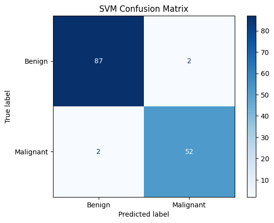

```
--- Confusion Matrix for Decision Tree ---
```

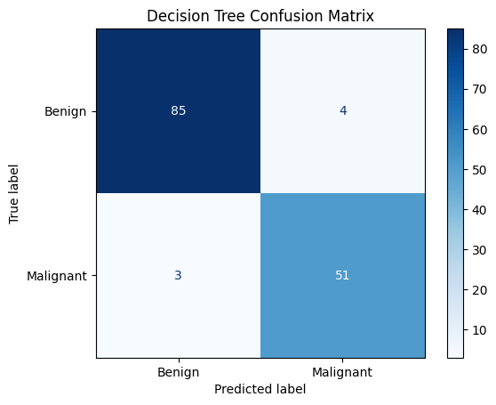

```
--- Confusion Matrix for Random Forest ---
```

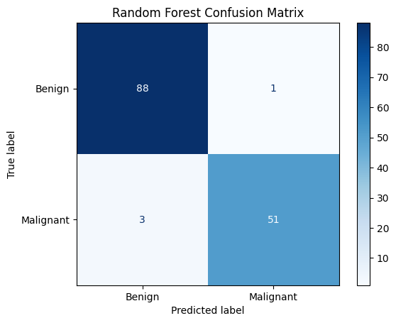

```python
from sklearn.metrics import confusion_matrix, ConfusionMatrixDisplay
import matplotlib.pyplot as plt

# --- Confusion Matrix for SVM ---
print("\n--- Confusion Matrix for SVM ---")
cm_svm = confusion_matrix(y_test, y_test_pred_svm)
disp_svm = ConfusionMatrixDisplay(confusion_matrix=cm_svm, display_labels=['Benign', 'Malignant'])
disp_svm.plot(cmap=plt.cm.Blues)
plt.title('SVM Confusion Matrix')
plt.show()

# --- Confusion Matrix for Decision Tree ---
print("\n--- Confusion Matrix for Decision Tree ---")
cm_dtree = confusion_matrix(y_test, y_test_pred_dtree)
disp_dtree = ConfusionMatrixDisplay(confusion_matrix=cm_dtree, display_labels=['Benign', 'Malignant'])
disp_dtree.plot(cmap=plt.cm.Blues)
plt.title('Decision Tree Confusion Matrix')
plt.show()

# --- Confusion Matrix for Random Forest ---
print("\n--- Confusion Matrix for Random Forest ---")
cm_rf = confusion_matrix(y_test, y_test_pred_rf)
disp_rf = ConfusionMatrixDisplay(confusion_matrix=cm_rf, display_labels=['Benign', 'Malignant'])
disp_rf.plot(cmap=plt.cm.Blues)
plt.title('Random Forest Confusion Matrix')
plt.show()
```

Prompt: Give Python code to evaluate Random Forest, SVM, and Decision Tree using 5-fold cross-validation and report mean accuracy and standard deviation

```python
from sklearn.model_selection import cross_val_score
import numpy as np

# --- SVM Cross-Validation ---
print("\n--- SVM Cross-Validation ---")
svm_cv_scores = cross_val_score(svm_model, X_train_scaled, y_train, cv=5, scoring='accuracy', n_jobs=-1)
print(f"SVM Mean Accuracy: {np.mean(svm_cv_scores):.4f}")
print(f"SVM Standard Deviation: {np.std(svm_cv_scores):.4f}")

# --- Decision Tree Cross-Validation ---
print("\n--- Decision Tree Cross-Validation ---")
dtree_cv_scores = cross_val_score(best_dtree_model, X_train_scaled, y_train, cv=5, scoring='accuracy', n_jobs=-1)
print(f"Decision Tree Mean Accuracy: {np.mean(dtree_cv_scores):.4f}")
print(f"Decision Tree Standard Deviation: {np.std(dtree_cv_scores):.4f}")

# --- Random Forest Cross-Validation ---
print("\n--- Random Forest Cross-Validation ---")
rf_cv_scores = cross_val_score(best_rf_model, X_train_scaled, y_train, cv=5, scoring='accuracy', n_jobs=-1)
print(f"Random Forest Mean Accuracy: {np.mean(rf_cv_scores):.4f}")
print(f"Random Forest Standard Deviation: {np.std(rf_cv_scores):.4f}")
```

```
--- SVM Cross-Validation ---
SVM Mean Accuracy: 0.9741
SVM Standard Deviation: 0.0137

--- Decision Tree Cross-Validation ---
Decision Tree Mean Accuracy: 0.9319
Decision Tree Standard Deviation: 0.0117

--- Random Forest Cross-Validation ---
Random Forest Mean Accuracy: 0.9624
Random Forest Standard Deviation: 0.0262
```

Inference: The Random Forest performs better than the Decision tree but fails to outperform SVM.

Prompt: Give Python code to train SVM, Decision tree, and Random Forest with class_weight='balanced' and evaluate performance

```python
from sklearn.svm import SVC
from sklearn.tree import DecisionTreeClassifier
from sklearn.ensemble import RandomForestClassifier
from sklearn.metrics import accuracy_score, precision_score, recall_score, roc_auc_score
import pandas as pd

# Dictionary to store model performance metrics with balanced class weights
balanced_model_performance = {}

# --- Support Vector Machine (SVM) with class_weight='balanced' ---
print("\n--- Support Vector Machine (SVM) with class_weight='balanced' ---")
svm_model_balanced = SVC(random_state=42, class_weight='balanced', probability=True) # probability=True for AUC
svm_model_balanced.fit(X_train_scaled, y_train)

y_test_pred_svm_balanced = svm_model_balanced.predict(X_test_scaled)
balanced_model_performance['SVM_Balanced'] = {
    'Accuracy': accuracy_score(y_test, y_test_pred_svm_balanced),
    'Precision': precision_score(y_test, y_test_pred_svm_balanced),
    'Recall': recall_score(y_test, y_test_pred_svm_balanced),
    'AUC': roc_auc_score(y_test, svm_model_balanced.predict_proba(X_test_scaled)[:, 1]) # Use predict_proba for AUC
}

# --- Decision Tree Classifier with class_weight='balanced' ---
print("\n--- Decision Tree Classifier with class_weight='balanced' ---")
dtree_model_balanced = DecisionTreeClassifier(random_state=42, class_weight='balanced')
dtree_model_balanced.fit(X_train_scaled, y_train)

y_test_pred_dtree_balanced = dtree_model_balanced.predict(X_test_scaled)
balanced_model_performance['Decision Tree_Balanced'] = {
    'Accuracy': accuracy_score(y_test, y_test_pred_dtree_balanced),
    'Precision': precision_score(y_test, y_test_pred_dtree_balanced),
    'Recall': recall_score(y_test, y_test_pred_dtree_balanced),
    'AUC': roc_auc_score(y_test, dtree_model_balanced.predict_proba(X_test_scaled)[:, 1])
}

# --- Random Forest Classifier with class_weight='balanced' ---
print("\n--- Random Forest Classifier with class_weight='balanced' ---")
rf_model_balanced = RandomForestClassifier(random_state=42, class_weight='balanced')
rf_model_balanced.fit(X_train_scaled, y_train)

y_test_pred_rf_balanced = rf_model_balanced.predict(X_test_scaled)
balanced_model_performance['Random Forest_Balanced'] = {
    'Accuracy': accuracy_score(y_test, y_test_pred_rf_balanced),
    'Precision': precision_score(y_test, y_test_pred_rf_balanced),
    'Recall': recall_score(y_test, y_test_pred_rf_balanced),
    'AUC': roc_auc_score(y_test, rf_model_balanced.predict_proba(X_test_scaled)[:, 1])
}

# Create a DataFrame from the balanced performance dictionary
balanced_performance_df = pd.DataFrame(balanced_model_performance).T

# Display the comparison table for balanced models
print("\nModel Performance Comparison (class_weight='balanced'):\n")
print(balanced_performance_df.round(4))
```

```
--- Support Vector Machine (SVM) with class_weight='balanced' ---

--- Decision Tree Classifier with class_weight='balanced' ---

--- Random Forest Classifier with class_weight='balanced' ---

Model Performance Comparison (class_weight='balanced'):

                        Accuracy  Precision  Recall     AUC
SVM_Balanced               0.958     0.9286  0.9630  0.9969
Decision Tree_Balanced     0.951     0.9273  0.9444  0.9498
Random Forest_Balanced     0.979     0.9811  0.9630  0.9986
```

Inference: Random Forest performs better than SVM on the balanced dataset in this particular test-train split.

Prompt: Give python code to draw confusion matrices for each of the models

```
--- Confusion Matrix for Balanced SVM ---
```

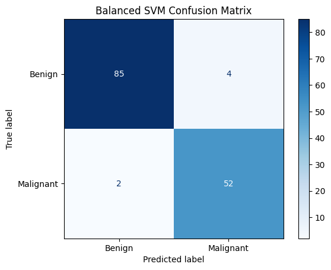

```
--- Confusion Matrix for Balanced Decision Tree ---
```

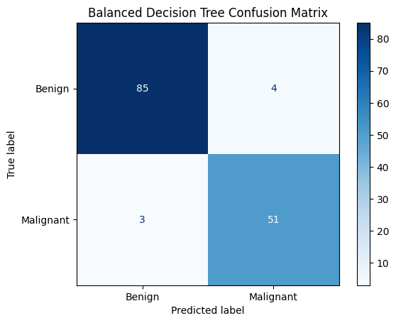

```
--- Confusion Matrix for Balanced Random Forest ---
```

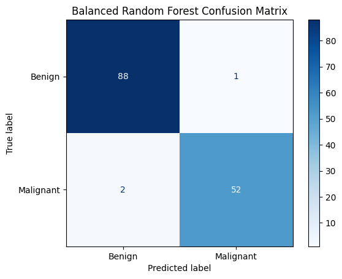

```python
from sklearn.metrics import confusion_matrix, ConfusionMatrixDisplay
import matplotlib.pyplot as plt

# --- Confusion Matrix for Balanced SVM ---
print("\n--- Confusion Matrix for Balanced SVM ---")
cm_svm_balanced = confusion_matrix(y_test, y_test_pred_svm_balanced)
disp_svm_balanced = ConfusionMatrixDisplay(confusion_matrix=cm_svm_balanced, display_labels=['Benign', 'Malignant'])
disp_svm_balanced.plot(cmap=plt.cm.Blues)
plt.title('Balanced SVM Confusion Matrix')
plt.show()

# --- Confusion Matrix for Balanced Decision Tree ---
print("\n--- Confusion Matrix for Balanced Decision Tree ---")
cm_dtree_balanced = confusion_matrix(y_test, y_test_pred_dtree_balanced)
disp_dtree_balanced = ConfusionMatrixDisplay(confusion_matrix=cm_dtree_balanced, display_labels=['Benign', 'Malignant'])
disp_dtree_balanced.plot(cmap=plt.cm.Blues)
plt.title('Balanced Decision Tree Confusion Matrix')
plt.show()

# --- Confusion Matrix for Balanced Random Forest ---
print("\n--- Confusion Matrix for Balanced Random Forest ---")
cm_rf_balanced = confusion_matrix(y_test, y_test_pred_rf_balanced)
disp_rf_balanced = ConfusionMatrixDisplay(confusion_matrix=cm_rf_balanced, display_labels=['Benign', 'Malignant'])
disp_rf_balanced.plot(cmap=plt.cm.Blues)
plt.title('Balanced Random Forest Confusion Matrix')
plt.show()
```

Prompt: Give python code to perform 5 fold cross validation on the balanced models

```python
from sklearn.model_selection import cross_val_score
import numpy as np

# --- Balanced SVM Cross-Validation ---
print("\n--- Balanced SVM Cross-Validation ---")
svm_cv_scores_balanced = cross_val_score(svm_model_balanced, X_train_scaled, y_train, cv=5, scoring='accuracy', n_jobs=-1)
print(f"Balanced SVM Mean Accuracy: {np.mean(svm_cv_scores_balanced):.4f}")
print(f"Balanced SVM Standard Deviation: {np.std(svm_cv_scores_balanced):.4f}")

# --- Balanced Decision Tree Cross-Validation ---
print("\n--- Balanced Decision Tree Cross-Validation ---")
dtree_cv_scores_balanced = cross_val_score(dtree_model_balanced, X_train_scaled, y_train, cv=5, scoring='accuracy', n_jobs=-1)
print(f"Balanced Decision Tree Mean Accuracy: {np.mean(dtree_cv_scores_balanced):.4f}")
print(f"Balanced Decision Tree Standard Deviation: {np.std(dtree_cv_scores_balanced):.4f}")

# --- Balanced Random Forest Cross-Validation ---
print("\n--- Balanced Random Forest Cross-Validation ---")
rf_cv_scores_balanced = cross_val_score(rf_model_balanced, X_train_scaled, y_train, cv=5, scoring='accuracy', n_jobs=-1)
print(f"Balanced Random Forest Mean Accuracy: {np.mean(rf_cv_scores_balanced):.4f}")
print(f"Balanced Random Forest Standard Deviation: {np.std(rf_cv_scores_balanced):.4f}")
```

```
--- Balanced SVM Cross-Validation ---
Balanced SVM Mean Accuracy: 0.9741
Balanced SVM Standard Deviation: 0.0203

--- Balanced Decision Tree Cross-Validation ---
Balanced Decision Tree Mean Accuracy: 0.9178
Balanced Decision Tree Standard Deviation: 0.0269

--- Balanced Random Forest Cross-Validation ---
Balanced Random Forest Mean Accuracy: 0.9554
Balanced Random Forest Standard Deviation: 0.0240
```

Inference: SVM performs better than Random Forest on the balanced dataset on average.